# MC 法求面积

22920242203150 2025-11-9

课程代码均在如下 GitHub 仓库开源：https://github.com/GHe0000/scientific-programming-intro

## 作业要求

已知心脏线的极坐标方程：

$$ \begin{aligned} \rho = 2a (1-\cos \phi) \end{aligned} $$

用撒点法求心脏线包围的面积，并通过计算探索散点数如何影响计算精度.

### 解析推导

要给出心脏线所围成的面积，在极座标中为如下积分：

$$ \begin{aligned} S &= \int_{0}^{2\pi} \frac{1}{2} [2a (1-\cos \phi)]^2 d\phi \\ &= \int_{0}^{2\pi} \frac{1}{2} [4a^2 (1 - 2\cos \phi + \cos^2 \phi)] d\phi \\ &= 2a^2 \int_{0}^{2\pi} (1 - 2\cos \phi + \cos^2 \phi) d\phi \\ &= 6\pi a^2 \end{aligned} $$

下面我们使用撒点法来计算.

## 撒点法计算

### 思路

撒点法（或者说 MC 方法）的思路都是将问题转化为某个随机变量的数字特征，并通过计算机模拟这个随机试验，并得到相应的数字特征，从而得到原始问题的解（或近似解）.

对于求解心脏线围成面积的问题，我们定义：

- 随机试验：在半径 $R=4a$ 的圆内，按均匀分布地随机抽取一个点
- 样本空间 $\Omega$：$R=4a$ 的圆内，所有点的集合
- 随机变量 $X$：令 $\omega \in \Omega$ ，令 $C$ 为心脏线所围成区域，则：

$$ X = \begin{cases} 1,\quad \omega \in C \\ 0,\quad \omega \notin C \end{cases} $$

则随机变量 $X$ 的期望 $\mathbb{E}[X]$ 为：

$$ \mathbb{E}[X] = \frac{S_x}{S_0} $$

其中 $S_x$ 是所要求的心脏线围成面积，$S_0$ 是 $R=4a$ 的圆形面积. 因此：

$$ S_x = S_0 \mathbb{E}[X] = 16 \pi a^2 \mathbb{E}[X] $$

综上我们将一个求面积的问题转化为求某个随机变量的期望的问题.

现在我们需要来通过模拟计算 $\mathbb{E}[X]$. 首先我们需要在圆内均匀取点. 这里我们将在圆内均匀取点转化为 $\phi$ 和 $\rho$ 的独立采样. 这里需要注意我们不能直接对 $\phi$ 和 $\rho$ 均匀采样，因为：

$$dS = \rho d \rho d\phi = d \left(\frac{1}{2} \rho^2 \right)d \phi$$

因此，$\rho$ 和 $\phi$ 分布满足：

- $\frac{1}{2} \rho^2 \sim U(0,8a) \Longrightarrow \rho \sim 4a \sqrt{U(0,1)} $
- $\phi \sim U(0,2\pi)$

其中 $U(a,b)$ 是从 $a$ 到 $b$ 的均匀分布.

给定一个取点 $(\rho,\phi)$. 比较 $\rho$ 和 $2a(1-\cos \phi)$. 如果小于，则取点在 $C$ 内，$X=1$. 反之 $X=0$.

我们知道: $\mathbb{E}[X] = \mathbb{P}[X=1]$. 而重复实验后可以用频率近似概率估计 $\mathbb{P}[X=1]$. 而频率容易在计算机中统计. 综上，我们给出了整个求解思路.

### 实现

这里我们先导入需要的库，并针对 Jupyter Notebook 进行一些设置.

```python
import numpy as np # 数值计算库
import numba as nb # 引入 jit 来加速函数（如果需要）
import sympy as sym # 符号计算库
import matplotlib as mpl
import matplotlib.pyplot as plt # 图像绘制
from matplotlib.backends.backend_agg import FigureCanvasAgg # 设置图像后端用
import ipywidgets as ipw # 交互控件
from IPython.display import display, Math, Latex # 打印数学公式


import matplotlib.animation as animation # 创建动画
from IPython.display import HTML # 动画嵌入
import scipy

# 使用 mathjax 来在 jupyter notebook 显示数学公式
sym.init_printing(use_latex='mathjax')

# 设置 matplotlib 绘制的图像嵌入到 jupyter notebook 的方式
%matplotlib widget

# 一个工具函数，可以让静态图片不经过 widget 直接嵌入 Jupyter notebook
# 这样图片可以直接存到 nb 文件里，而不是需要运行才能显示（类似 inline）
def display_inline(fig):
    fig.set_canvas(FigureCanvasAgg(fig))
    display(fig)
    plt.close(fig) # 释放 fig，减小资源消耗

# 一个工具函数，用于在 Jupyter 中快速实现公式和字符串混合输出
def display_math(*args):
    parts = []
    for a in args:
        if isinstance(a, str):
            parts.append(a)
        else:
            parts.append(sym.latex(a))
    display(Math("".join(parts)))

# 设置 matplotlib 使用的字体，避免出现中文问题
plt.rcParams['font.family'] = ['SimSun', 'Times New Roman']
plt.rcParams['mathtext.fontset'] = 'cm'
# 设置默认坐标轴字体大小
plt.rcParams['axes.labelsize'] = 14
```

这里我们设定随机数种子以确保结果的可复现性.

```python
np.random.seed(3407)
```

下面我们根据前文所述方法，随机取点，并统计在心脏线内的点的频率. 给出估计值.

不失一般性，后文中我们均假设 $a=1$.（不同的 $a$ 只是缩放了大小）

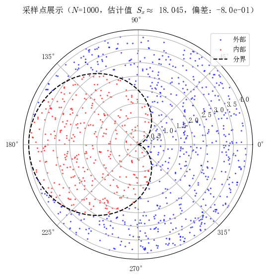

```python
N = 1000

phi_samps = np.random.uniform(0, 2*np.pi, N)
rho_samps = 4 * np.sqrt(np.random.uniform(0, 1, N))
inside_idx = (rho_samps <= 2*(1-np.cos(phi_samps)))
N_inside = np.sum(inside_idx)

S0 = 16 * np.pi
S_exact = 6 * np.pi
Sx = S0 * (N_inside / N)
#print(Sx)

plt_N = min(N,20000)
plt_idx = np.random.choice(N, plt_N, replace=False)
phi_plt = phi_samps[plt_idx]
rho_plt = rho_samps[plt_idx]
inside_plt = inside_idx[plt_idx]
fig = plt.figure(figsize=(8,6))
ax = plt.subplot(111, projection='polar')
ax.scatter(phi_plt[~inside_plt], rho_plt[~inside_plt], color='blue', s=2, alpha=0.5, label="外部")
ax.scatter(phi_plt[inside_plt], rho_plt[inside_plt], color='red', s=2, alpha=0.5, label="内部")
phi_bnd = np.linspace(0, 2 * np.pi, 400)
rho_bnd = 2*(1-np.cos(phi_bnd))
ax.plot(phi_bnd, rho_bnd, "k--", label="分界")
ax.legend()
ax.set_title(f"采样点展示（$N$={N}，估计值 $S_x\\approx$ {Sx:.3f}，偏差：{Sx-S_exact:.1e}）")
display_inline(fig)
```

我们可以提升点的数量来进行更精确的估计.

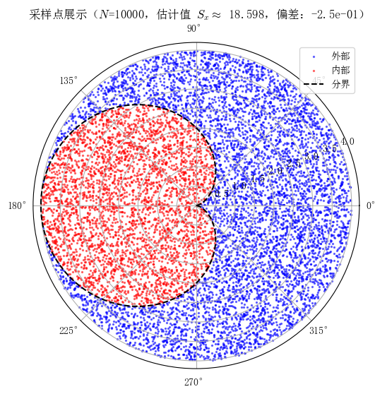

```python
N = 10000

phi_samps = np.random.uniform(0, 2*np.pi, N)
rho_samps = 4 * np.sqrt(np.random.uniform(0, 1, N))
inside_idx = (rho_samps <= 2*(1-np.cos(phi_samps)))
N_inside = np.sum(inside_idx)

S0 = 16 * np.pi
S_exact = 6 * np.pi
Sx = S0 * (N_inside / N)
#print(Sx)

plt_N = min(N,20000)
plt_idx = np.random.choice(N, plt_N, replace=False)
phi_plt = phi_samps[plt_idx]
rho_plt = rho_samps[plt_idx]
inside_plt = inside_idx[plt_idx]
fig = plt.figure(figsize=(8,6))
ax = plt.subplot(111, projection='polar')
ax.scatter(phi_plt[~inside_plt], rho_plt[~inside_plt], color='blue', s=2, alpha=0.5, label="外部")
ax.scatter(phi_plt[inside_plt], rho_plt[inside_plt], color='red', s=2, alpha=0.5, label="内部")
phi_bnd = np.linspace(0, 2 * np.pi, 400)
rho_bnd = 2*(1-np.cos(phi_bnd))
ax.plot(phi_bnd, rho_bnd, "k--", label="分界")
ax.legend()
ax.set_title(f"采样点展示（$N$={N}，估计值 $S_x\\approx$ {Sx:.3f}，偏差：{Sx-S_exact:.1e}）")
display_inline(fig)
```

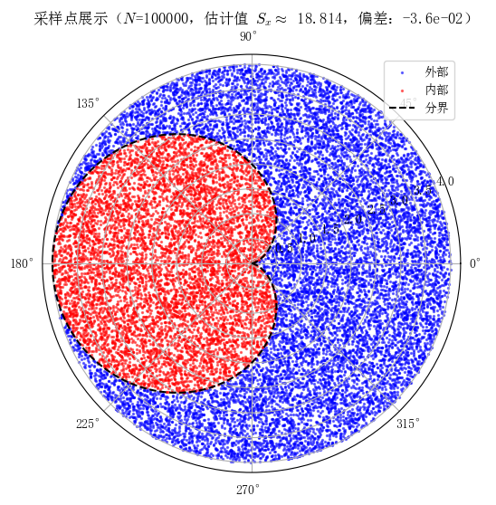

```python
N = 100000

phi_samps = np.random.uniform(0, 2*np.pi, N)
rho_samps = 4 * np.sqrt(np.random.uniform(0, 1, N))
inside_idx = (rho_samps <= 2*(1-np.cos(phi_samps)))
N_inside = np.sum(inside_idx)

S0 = 16 * np.pi
S_exact = 6 * np.pi
Sx = S0 * (N_inside / N)
#print(Sx)

plt_N = min(N,20000)
plt_idx = np.random.choice(N, plt_N, replace=False)
phi_plt = phi_samps[plt_idx]
rho_plt = rho_samps[plt_idx]
inside_plt = inside_idx[plt_idx]
fig = plt.figure(figsize=(8,6))
ax = plt.subplot(111, projection='polar')
ax.scatter(phi_plt[~inside_plt], rho_plt[~inside_plt], color='blue', s=2, alpha=0.5, label="外部")
ax.scatter(phi_plt[inside_plt], rho_plt[inside_plt], color='red', s=2, alpha=0.5, label="内部")
phi_bnd = np.linspace(0, 2 * np.pi, 400)
rho_bnd = 2*(1-np.cos(phi_bnd))
ax.plot(phi_bnd, rho_bnd, "k--", label="分界")
ax.legend()
ax.set_title(f"采样点展示（$N$={N}，估计值 $S_x\\approx$ {Sx:.3f}，偏差：{Sx-S_exact:.1e}）")
display_inline(fig)
```

可以看见，随着取点越来越多，估计值越来越接近理论值. 下面我们探讨撒点数量和精度的关系.

## 撒点数量与精度关系

### 理论：中心极限（CLT）

首先，我们先介绍概率论中非常重要的一个定理：中心极限定理（CLT）：

$\mathbf{Theorem}:$ 独立同分布（i.i.d.）的且数学期望和方差均有限的随机变量，即设 $\mathbb{E}[X]=\mu$, $\mathbb{D}[X]=\sigma^2$，记： $$ \bar{X} = \frac{1}{N}\sum_{k=1}^N X_k $$ 有依分布收敛： $$ Z = \frac{\bar{X}-\mu}{\sigma / \sqrt{N}} \xrightarrow{d} N(0,1) $$ 也就是： $$ \sqrt{N} \left( \bar{X}-\mu \right) \xrightarrow{d} N(0,\sigma^2) $$ 其中 $N(a,b)$ 为均值为 $a$，方差为 $b$ 的正态分布.

CLT 给出了均值 $\bar{X}$ 的分布. 我们记 $\bar{X}$ 和 $\mu$ 的偏差（也就是模拟值和理论值的误差）为 $E$. 因此 $E$ 的分布满足：

$$ \sqrt{N} E \sim N(0,\sigma^2) $$

因此，$E$ 应该与 $1/\sqrt{N}$ 成正比. 或者说：$\log E - \log N$ 图应该是一条直线，且斜率为 $-1/2$.

另一方面，我们也可以解析求解出方差. 易知落入心脏线内的概率 $p=S_x/S_0$. 对于随机变量 $X$，其符合 Bernoulli 分布，其方差为：

$$ \mathbb{D}[X] = p(1-p) $$

而 $E=S_x - S_{exact} = X \cdot S_0 - S_{exact} $，故：

$$ \sqrt{N}E \sim N(0, \sigma^2) $$

其中：

$$\sigma^2 = S_0^2 \mathbb{D}[X] = S_0^2 p(1-p) $$

### 数值验证 1

下面我们给出数值验证. 我们在 $10^3$ 到 $10^6$ 次方之间取多个 $N$. 对于每一个 $N$，我们用 MC 估计面积，并和解析结果进行对比，得到 $E$. 重复 $m=10$ 次，得到 $\bar{E}$（这里是为了避免单次计算的 $E$ 的随机性）. 我们在 $\log-\log$ 图中绘制 $\bar{E}$ 和 $n$ 的图像.

```python
m = 10
n_N = 20
N_arr = np.logspace(3, 6, num=n_N).astype(int)
E_arr = np.zeros(n_N)
for i,N in enumerate(N_arr):
    phi_samps = np.random.uniform(0, 2*np.pi, (N,m))
    rho_samps = 4 * np.sqrt(np.random.uniform(0, 1, (N,m)))
    inside_idx = (rho_samps <= 2*(1-np.cos(phi_samps)))
    N_inside = np.sum(inside_idx, axis=0)
    S0 = 16 * np.pi
    S_exact = 6 * np.pi
    Sx = S0 * (N_inside / N)
    Ex = np.abs(Sx-S_exact)
    E_arr[i]=np.mean(Ex)
```

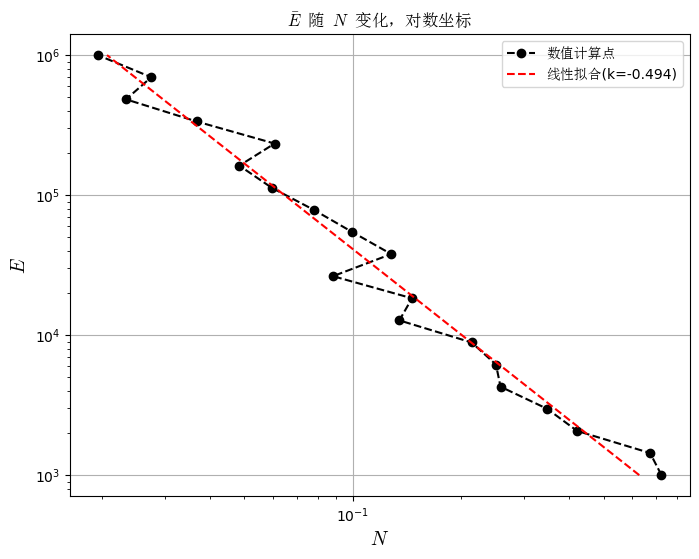

```python
plt.rcParams['font.family'] = ['DejaVu Sans','SimSun', 'Times New Roman'] # 临时设置字体，消除上标的负号问题
fig, ax = plt.subplots(figsize=(8,6))
ax.loglog()

k_fit ,b_fit = np.polyfit(np.log(N_arr), np.log(E_arr), deg=1)
N_fit = np.logspace(3, 6, num=200)
fit_line = np.exp(b_fit) * (N_fit ** k_fit)

ax.plot(E_arr,N_arr,"k--o",label="数值计算点")
ax.plot(fit_line, N_fit, "r--", label=f"线性拟合(k={k_fit:.3f})")
ax.set_title("$\\bar{E}$ 随 $N$ 变化，对数坐标",  fontfamily="SimSun")
ax.set_xlabel("$N$")
ax.set_ylabel("$E$")
ax.grid()
ax.legend()
plt.rcParams['font.family'] = ['SimSun', 'Times New Roman']
display_inline(fig)
```

可以看见，线性拟合结果为 $k=-0.494$ 接近前文推导值 $-0.5$. 我们可以增大 $m$ 观察曲线.

```python
m = 100
n_N = 20
N_arr = np.logspace(3, 6, num=n_N).astype(int)
E_arr = np.zeros(n_N)
for i,N in enumerate(N_arr):
    phi_samps = np.random.uniform(0, 2*np.pi, (N,m))
    rho_samps = 4 * np.sqrt(np.random.uniform(0, 1, (N,m)))
    inside_idx = (rho_samps <= 2*(1-np.cos(phi_samps)))
    N_inside = np.sum(inside_idx, axis=0)
    S0 = 16 * np.pi
    S_exact = 6 * np.pi
    Sx = S0 * (N_inside / N)
    Ex = np.abs(Sx-S_exact)
    E_arr[i]=np.mean(Ex)
```

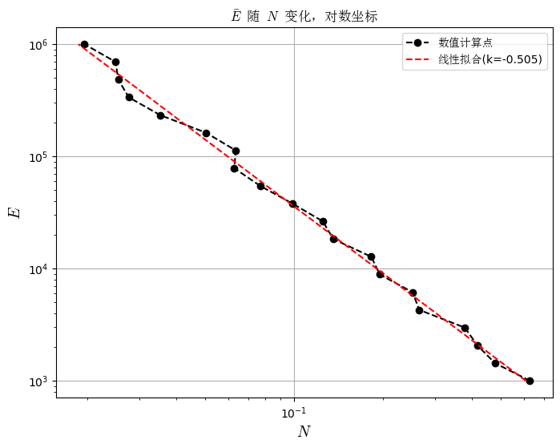

```python
plt.rcParams['font.family'] = ['DejaVu Sans','SimSun', 'Times New Roman'] # 临时设置字体，消除上标的负号问题
fig, ax = plt.subplots(figsize=(8,6))
ax.loglog()

k_fit ,b_fit = np.polyfit(np.log(N_arr), np.log(E_arr), deg=1)
N_fit = np.logspace(3, 6, num=200)
fit_line = np.exp(b_fit) * (N_fit ** k_fit)

ax.plot(E_arr,N_arr,"k--o",label="数值计算点")
ax.plot(fit_line, N_fit, "r--", label=f"线性拟合(k={k_fit:.3f})")
ax.set_title("$\\bar{E}$ 随 $N$ 变化，对数坐标",  fontfamily="SimSun")
ax.set_xlabel("$N$")
ax.set_ylabel("$E$")
ax.grid()
ax.legend()
plt.rcParams['font.family'] = ['SimSun', 'Times New Roman']
display_inline(fig)
```

可以看到，数值计算的点更接近于直线. 且 $k$ 更接近 $-0.5$. 这说明我们前面的理论推导是正确的.

### 数值验证 2

前面的数值计算给出了 $E$ 随 $N$ 的关系. 为了说明 $E$ 确实符合正态分布. 也就是：

$$ \sqrt{N}E \sim N(0, S_0^2 p(1-p)) $$

我们绘制 $\sqrt{N} E$ 的直方图，并和理论进行对比.

我们固定一个 $N$. 重复 $m$ 次. 绘制 $\sqrt{N} E$ 的直方图. 如下：

```python
N = 1000
m = 10000

S0 = 16 * np.pi
S_exact = 6 * np.pi

phi_samps = np.random.uniform(0, 2*np.pi, (N, m))
rho_samps = 4 * np.sqrt(np.random.uniform(0, 1, (N, m)))
inside_idx = (rho_samps <= 2*(1 - np.cos(phi_samps)))

N_inside = np.sum(inside_idx, axis=0)
Sx = S0 * (N_inside / N)
Ex = Sx - S_exact
```

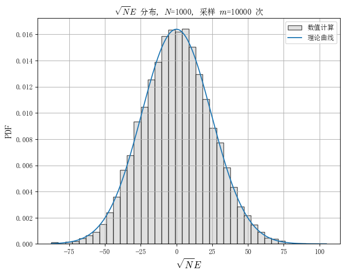

```python
p = S_exact / S0
sigma = np.sqrt(p * (1 - p)) * S0
mu = 0.0

fig, ax = plt.subplots(figsize=(8,6))
count, bins, _ = ax.hist(Ex*np.sqrt(N), bins=40, density=True, color='lightgray', edgecolor='k', alpha=0.7, label="数值计算")
x_fit = np.linspace(bins[0], bins[-1], 300)
y_fit = (1 / (np.sqrt(2*np.pi) * sigma)) * np.exp(-0.5 * ((x_fit - mu) / sigma)**2)
ax.plot(x_fit, y_fit, label="理论曲线")
ax.grid()
ax.set_xlabel("$\\sqrt{N}E$")
ax.set_ylabel("PDF")
ax.set_title(f"$\\sqrt{{N}}E$ 分布, $N$={N}, 采样 $m$={m} 次")
ax.legend()
display_inline(fig)
```

可以看到，数值和理论非常吻合.

## 参考资料

- 盛骤等, 概率论与数理统计, 第五版. §5.2 中心极限定理
- 部分代码编写时使用 Fitten Code AI 进行补全
- 代码实现中使用 Google Gemini AI 查询了一些函数的用法.

## 致谢

暂无

## 附一：问题

- 在我以前参加的一个非平衡热学的报告中了解到了概率论中的“大偏差理论”(LDT). 具体而言，其给出了 $\bar{X}$ 偏离 $\mu$ 较大时的的概率： $$ P(\bar{X}=x)=e^{-NI(x)} $$ 其中 $I(x)$ 为速率函数. $$ I(s) = \sup_{\lambda \in \mathbb{R}} [\lambda s - \log M(\lambda)] $$ 其中 $M = \mathbb{E}[e^{\lambda X}]$. 换句话说对于一个罕见的大偏差，其发生概率的衰减为指数量级的. 综上有问题如下：
  - LDT 和 CLT 的关系？（数学问题）
  - 如何在 MC 估计面积中验证 LDT？（尝试过，但概率太小比较难实现）

## 附二：学习心得

- MC 法估计面积
- 极座标绘图